# OBIS tools for QA/QC

2018-02-09

## Getting started

Installation

```r
# install.packages("devtools")
devtools::install_github('iobis/obistools')

library(obistools)
```

Help and issues

- Manual: http://www.iobis.org/manual/processing/
- Issues: https://github.com/iobis/obistools/issues

## Generate a report

View points on a map and check missing fields, event dates, depth values, points on land, …

```r
report(abra, file="abra_report.html", dir=".")
```

abra_report.html

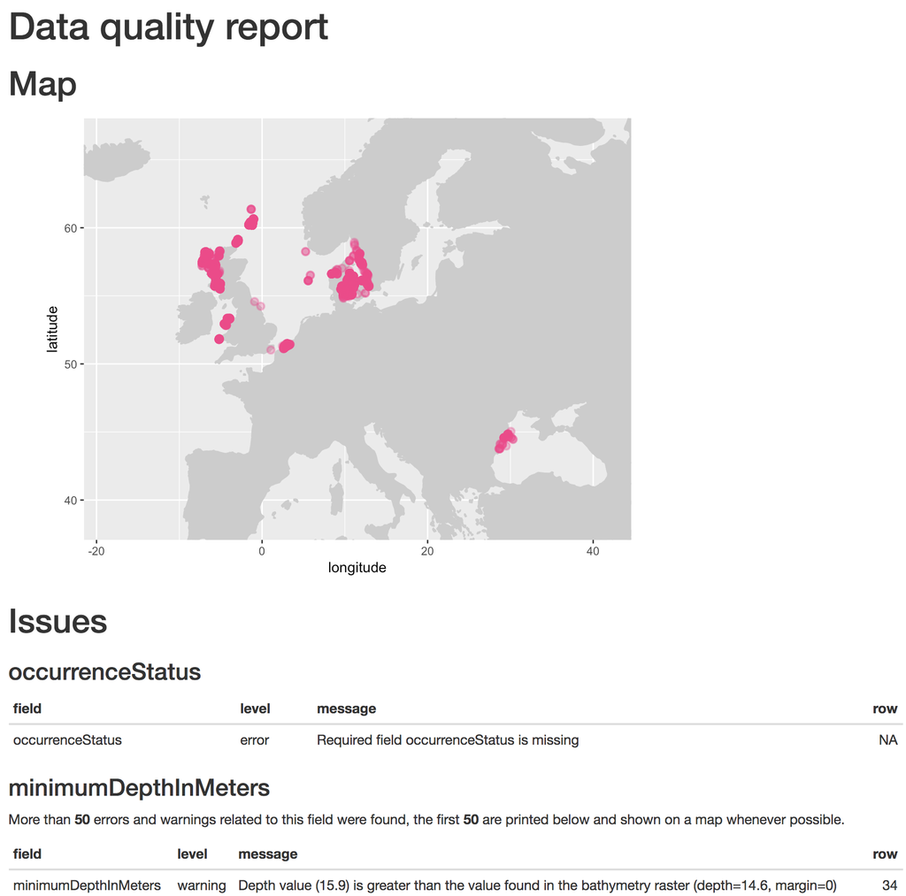

## Check required fields

```r
check_fields(abra)
```

```
##              field level                                    message
## 1 occurrenceStatus error Required field occurrenceStatus is missing
```

occurrenceStatus: A statement about the presence or absence of a Taxon at a Location.  
http://rs.tdwg.org/dwc/terms/#occurrenceStatus

## Map column names to Darwin Core terms

```r
data <- data.frame(
  id = c("cruise_1", "station_1", "station_2", "sample_1", "sample_2", "sample_3", "sample_4", "subsample_1", "subsample_2"),
  date = c(NA, NA, NA, "2017-01-01", "2017-01-02", "2017-01-03", "2017-01-04", NA, NA),
  locality = rep("North Sea", 9),
  lon = c(NA, 2.9, 4.7, NA, NA, NA, NA, NA, NA),
  lat = c(NA, 54.1, 55.8, NA, NA, NA, NA, NA, NA),
  stringsAsFactors = FALSE)

mapping <- list(
  decimalLongitude = "lon", decimalLatitude = "lat",
  datasetName = "dataset", eventID = "id", eventDate = "date")
```

[Issue 56: detect_fields](https://github.com/iobis/obistools/issues/56)

## Map column names to Darwin Core terms

```r
map_fields(data, mapping)
```

```
##       eventID  eventDate  locality decimalLongitude decimalLatitude
## 1    cruise_1       <NA> North Sea               NA              NA
## 2   station_1       <NA> North Sea              2.9            54.1
## 3   station_2       <NA> North Sea              4.7            55.8
## 4    sample_1 2017-01-01 North Sea               NA              NA
## 5    sample_2 2017-01-02 North Sea               NA              NA
## 6    sample_3 2017-01-03 North Sea               NA              NA
## 7    sample_4 2017-01-04 North Sea               NA              NA
## 8 subsample_1       <NA> North Sea               NA              NA
## 9 subsample_2       <NA> North Sea               NA              NA
```

## Taxon matching

Interactive taxon matching with the World Register of Marine Species (WoRMS)

```r
taxa <- c("Abra alva", "Buccinum fusiforme", "Buccinum fusiforme", "hlqsdkf")
matched_taxa <- match_taxa(taxa)
matched_taxa
```

```
3 names, 1 without matches, 1 with multiple matches
Proceed to resolve names (y/n/p)? y

  AphiaID     scientificname      authority     status match_type
1  531014 Buccinum fusiforme   Kiener, 1834 unaccepted      exact
2  510389 Buccinum fusiforme Broderip, 1830 unaccepted      exact

Multiple matches, pick a number or leave empty to skip: 2
```

```
##       scientificName                          scientificNameID matche_type
## 1          Abra alba urn:lsid:marinespecies.org:taxname:141433      near_1
## 2 Buccinum fusiforme urn:lsid:marinespecies.org:taxname:510389       exact
## 3 Buccinum fusiforme urn:lsid:marinespecies.org:taxname:510389       exact
## 4               <NA>                                      <NA>        <NA>
```

## Checking points on land

```r
onland <- check_onland(abra)
onland[,1:5]
```

```
##           id decimalLongitude decimalLatitude basisOfRecord
## 31 365512845       -0.9092748        54.57467    Occurrence
##              eventDate
## 31 2011-09-03 10:00:00
```

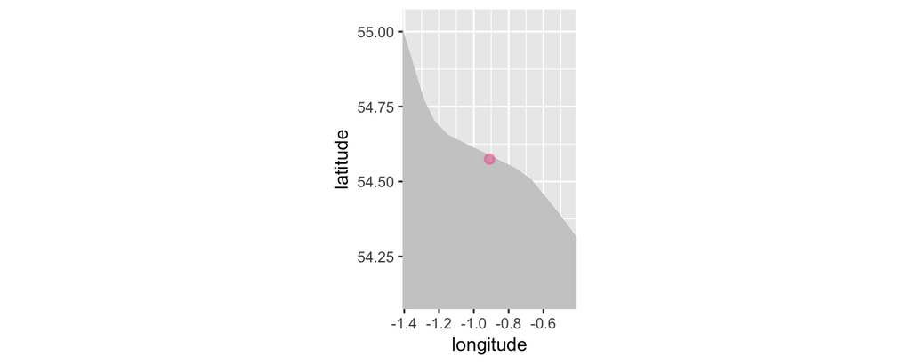

```r
plot_map(onland, zoom = TRUE)
```

```r
robis::leafletmap(onland)
```

[interactive chart not shown]

## Checking depth values

```r
depthreport <- check_depth(abra, report = TRUE)
depthreport[1:10, ]
```

```
##                   field   level row
## 1  minimumDepthInMeters warning  34
## 2  minimumDepthInMeters warning  35
## 3  minimumDepthInMeters warning  36
## 4  minimumDepthInMeters warning  37
## 5  minimumDepthInMeters warning  47
## 6  minimumDepthInMeters warning  51
## 7  minimumDepthInMeters warning  52
## 8  minimumDepthInMeters warning  54
## 9  minimumDepthInMeters warning  55
## 10 minimumDepthInMeters warning  56
##                                                                                               message
## 1  Depth value (15.9) is greater than the value found in the bathymetry raster (depth=14.6, margin=0)
## 2  Depth value (15.9) is greater than the value found in the bathymetry raster (depth=14.6, margin=0)
## 3  Depth value (23.7) is greater than the value found in the bathymetry raster (depth=20.2, margin=0)
## 4  Depth value (24.8) is greater than the value found in the bathymetry raster (depth=20.2, margin=0)
## 5  Depth value (19.4) is greater than the value found in the bathymetry raster (depth=18.6, margin=0)
## 6  Depth value (23.4) is greater than the value found in the bathymetry raster (depth=18.6, margin=0)
## 7  Depth value (23.8) is greater than the value found in the bathymetry raster (depth=18.6, margin=0)
## 8    Depth value (8.5) is greater than the value found in the bathymetry raster (depth=7.2, margin=0)
## 9   Depth value (8.75) is greater than the value found in the bathymetry raster (depth=7.2, margin=0)
## 10   Depth value (8.9) is greater than the value found in the bathymetry raster (depth=7.2, margin=0)
```

## Checking depth values

```r
robis::leafletmap(abra[depthreport$row,])
```

[interactive chart not shown]

## Checking depth values

Extra parameters for `check_depth`:

- `depthmargin`: How much can the given depth deviate from the bathymetry in the rasters (in meters).
- `shoremargin`: How far offshore (in meters) should a record be to have a bathymetry greater than 0. If NA (default) then this test is ignored.
- `bathymetry`: Raster* object that you want to use to check the depth against. If NULL (default) then the bathymetry from the xylookup service is used.

## Lookup XY

Data for on land and depth checks is provided by the xylookup service which can be called trough the `lookup_xy` function.

```r
env <- lookup_xy(abra)
head(env)
```

```
##   shoredistance sstemperature sssalinity bathymetry
## 1            30       10.2863    34.7627       -4.0
## 2          1080       10.3324    34.9062       61.4
## 3          1184       10.7220    34.8890      122.2
## 4           290       10.7920    34.2934       20.6
## 5           259       10.7220    34.8890       51.0
## 6           506       10.7710    34.3070       32.4
```

## Check event date

```r
data_nodate <- data.frame(
  scientificName = c("Abra alba", "Lanice conchilega"),
  stringsAsFactors = FALSE)

check_eventdate(data_nodate)
```

```
##   level                  message
## 1 error Column eventDate missing
```

## Check event date

```r
data_goodformats <- data.frame(
  eventDate = c(
    "2016",
    "2016-01",
    "2016-01-02",
    "2016-01-02 13:00",
    "2016-01-02T13:00",
    "2016-01-02 13:00:00/2016-01-02 14:00:00",
    "2016-01-02 13:00:00/14:00:00"),
  stringsAsFactors = FALSE)

check_eventdate(data_goodformats)
```

```
## data frame with 0 columns and 0 rows
```

## Check event date

```r
data_badformats <- data.frame(
  eventDate = c(
    "2016/01/02",
    "2016-01-02 13h00"),
  stringsAsFactors = FALSE)

check_eventdate(data_badformats)
```

```
##   level row     field
## 1 error   1 eventDate
## 2 error   2 eventDate
##                                                       message
## 1       eventDate 2016/01/02 does not seem to be a valid date
## 2 eventDate 2016-01-02 13h00 does not seem to be a valid date
```

## Dataset structure

```r
archive <- hyperbenthos$data
archive$extendedmeasurementorfact.txt$eventID <- archive$extendedmeasurementorfact.txt$id
tree <- obistools::treeStructure(archive$event.txt, archive$occurrence.txt,
                      archive$extendedmeasurementorfact.txt)
exportTree(tree, "hyperbenthos_tree.html")
```

hyperbenthos_tree.html

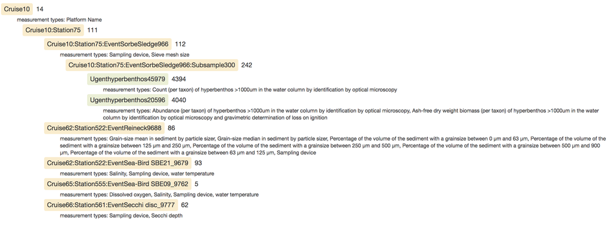

## Check eventID and parentEventID

`check_eventids()` checks if both `eventID()` and `parentEventID` fields are present in an event table, and if al `parentEventID`s have a corresponding `eventID`.

```r
data <- data.frame(
  eventID = c("a", "b", "c", "d", "e", "f"),
  parentEventID = c("", "", "a", "a", "z", "b"),
  stringsAsFactors = FALSE
)
check_eventids(data)
```

```
##           field level row                                      message
## 1 parentEventID error   5 parentEventID z has no corresponding eventID
```

## Check eventID in an extension

`check_extension_eventids()` checks if all `eventID`s in an extension have matching `eventID`s in the core table.

```r
event <- data.frame(
  eventID = c("cruise_1", "station_1", "station_2",
              "sample_1", "sample_2", "sample_3", "sub_1", "sub_2"),
  parentEventID = c(NA, "cruise_1", "cruise_1", "station_1", "station_1", "station_2",
                    "sample_3", "sample_3"),
  eventDate = c(NA, NA, NA, "2017-01-01", "2017-01-02", "2017-01-03", NA, NA),
  decimalLongitude = c(NA, 2.9, 4.7, NA, NA, NA, NA, NA),
  decimalLatitude = c(NA, 54.1, 55.8, NA, NA, NA, NA, NA),
  stringsAsFactors = FALSE)

event
```

```
##     eventID parentEventID  eventDate decimalLongitude decimalLatitude
## 1  cruise_1          <NA>       <NA>               NA              NA
## 2 station_1      cruise_1       <NA>              2.9            54.1
## 3 station_2      cruise_1       <NA>              4.7            55.8
## 4  sample_1     station_1 2017-01-01               NA              NA
## 5  sample_2     station_1 2017-01-02               NA              NA
## 6  sample_3     station_2 2017-01-03               NA              NA
## 7     sub_1      sample_3       <NA>               NA              NA
## 8     sub_2      sample_3       <NA>               NA              NA
```

## Check eventID in an extension

```r
occurrence <- data.frame(
  eventID = c("sample_1","sample_1","sample_28","sample_2","sample_3","sub_1"),
  scientificName = c("Abra alba", "Lanice conchilega", "Pectinaria koreni",
                     "Nephtys hombergii", "Pectinaria koreni", "Abra alba"),
  stringsAsFactors = FALSE)

occurrence
```

```
##     eventID    scientificName
## 1  sample_1         Abra alba
## 2  sample_1 Lanice conchilega
## 3 sample_28 Pectinaria koreni
## 4  sample_2 Nephtys hombergii
## 5  sample_3 Pectinaria koreni
## 6     sub_1         Abra alba
```

## Check eventID in an extension

```r
check_extension_eventids(event, occurrence)
```

```
##     field level row
## 1 eventID error   3
##                                                      message
## 1 eventID sample_28 has no corresponding eventID in the core
```

## Flatten event records

`flatten_event()` recursively adds event information from parent to child events.

```r
event
```

```
##     eventID parentEventID  eventDate decimalLongitude decimalLatitude
## 1  cruise_1          <NA>       <NA>               NA              NA
## 2 station_1      cruise_1       <NA>              2.9            54.1
## 3 station_2      cruise_1       <NA>              4.7            55.8
## 4  sample_1     station_1 2017-01-01               NA              NA
## 5  sample_2     station_1 2017-01-02               NA              NA
## 6  sample_3     station_2 2017-01-03               NA              NA
## 7     sub_1      sample_3       <NA>               NA              NA
## 8     sub_2      sample_3       <NA>               NA              NA
```

```r
flatten_event(event)
```

```
##     eventID parentEventID  eventDate decimalLongitude decimalLatitude
## 1  cruise_1          <NA>       <NA>               NA              NA
## 2 station_1      cruise_1       <NA>              2.9            54.1
## 3 station_2      cruise_1       <NA>              4.7            55.8
## 4  sample_1     station_1 2017-01-01              2.9            54.1
## 5  sample_2     station_1 2017-01-02              2.9            54.1
## 6  sample_3     station_2 2017-01-03              4.7            55.8
## 7     sub_1      sample_3 2017-01-03              4.7            55.8
## 8     sub_2      sample_3 2017-01-03              4.7            55.8
```

## Flatten occurrence and event records

`flatten_occurrence()` will add event information to occurrence records.

```r
occurrence
```

```
##     eventID    scientificName
## 1  sample_1         Abra alba
## 2  sample_1 Lanice conchilega
## 3 sample_28 Pectinaria koreni
## 4  sample_2 Nephtys hombergii
## 5  sample_3 Pectinaria koreni
## 6     sub_1         Abra alba
```

```r
occurrence[occurrence$eventID=="sample_28",] <- "sample_2"
flatten_occurrence(event, occurrence)
```

```
##    eventID    scientificName  eventDate decimalLatitude decimalLongitude
## 1 sample_1         Abra alba 2017-01-01            54.1              2.9
## 2 sample_1 Lanice conchilega 2017-01-01            54.1              2.9
## 3 sample_2          sample_2 2017-01-02            54.1              2.9
## 4 sample_2 Nephtys hombergii 2017-01-02            54.1              2.9
## 5 sample_3 Pectinaria koreni 2017-01-03            55.8              4.7
## 6    sub_1         Abra alba 2017-01-03            55.8              4.7
```

## Calculate centroid and radius for WKT geometries

WKT: text representation for geometries https://en.wikipedia.org/wiki/Well-known_text

```
POINT (30 10)
LINESTRING (30 10, 10 30, 40 40)
POLYGON ((30 10, 40 40, 20 40, 10 20, 30 10))
```

`calculate_centroid()` calculates a centroid and radius for WKT strings. This is useful for populating `decimalLongitiude`, `decimalLatitude` and `coordinateUncertaintyInMeters`.

```r
wkt <- c(
  "POLYGON ((2.5378 51.1242, 2.9937 51.3203, 3.3453 51.3957, 2.2741 51.6998, 2.5378 51.1242))",
  "POLYGON ((3.1558 42.2356, 3.1324 42.1420, 3.2203 42.1124, 3.2601 42.2153, 3.1558 42.2356))"
)
centroid <- calculate_centroid(wkt)
centroid
```

```
##   decimalLongitude decimalLatitude coordinateUncertaintyInMeters
## 1         2.719067        51.40717                     44860.608
## 2         3.193506        42.17714                      7524.069
```

## Centroid and radius for WKT

```r
if(!requireNamespace("sf")){
  install.packages(sf)
}
features <- sf::st_as_sfc(wkt)
map <- robis::leafletmap(centroid)
leaflet::addPolygons(map, data = features)
```

[interactive chart not shown]